# CE-315: Teorema de Bayes

Exemplos com formatação para solução

PJ

# Exemplo 1: Teste diagnóstico de uma doença rara

Considere o problema do teste diagnóstico de uma doença rara, que afeta 2% da população. Um teste diagnóstico para a doença tem sensibilidade de 90% e especificidade de 80%. Ou seja, se uma pessoa tem a doença, o teste dá positivo com probabilidade 90%, e se a pessoa não tem a doença, o teste dá negativo com probabilidade 80%. O objetivo é determinar a probabilidade de uma pessoa ter ou não a doença dado que o teste deu positivo.

Definindo notação:

- $D$ : evento “a pessoa tem a doença”
- $T$ : evento “o teste deu positivo”
- $P(D) = 0.02$ : prevalência da doença na população
- $P(T|D) = 0.9$ : sensibilidade do teste
- $P(T|D^c) = 0.2$ : taxa de falso positivo (1 - especificidade)

Redefinindo notação:

- parâmetro $\theta \in \{0, 1\}$
  $$\theta = \begin{cases}
  0 & \text{se não tem a doença}\\
  1 & \text{se tem a doença}
  \end{cases}$$
- variável observada $Y \in \{0, 1\}$
  $$Y = \begin{cases}
  0 & \text{se o teste é negativo}\\
  1 & \text{se o teste é positivo}
  \end{cases}$$
- $P(\theta = 0) = 0.98$ e $P(\theta = 1) = 0.02$
- $P(Y = 0 | \theta = 0) = 0.8$ e $P(Y = 1 | \theta = 1) = 0.9$
- $P(Y = 0 | \theta = 1) = 0.1$ e $P(Y = 1 | \theta = 0) = 0.2$

Priori: $P(\theta)$  
Para teste POSITIVO:  
Verossimilhança: $P(Y = 1 | \theta)$

```r
ex01.1 <- tibble::tibble(
  theta = c(0,1),
  priori = c(0.98, 0.02),
  vero = c(0.20, 0.90),
  produto = priori * vero,
  posteriori = produto/sum(produto)
)
knitr::kable(ex01.1)
```

| theta | priori | vero | produto | posteriori |
| --- | --- | --- | --- | --- |
| 0 | 0.98 | 0.2 | 0.196 | 0.9158879 |
| 1 | 0.02 | 0.9 | 0.018 | 0.0841121 |

```r
ex01.2 <- tibble::tibble(
  theta = c(0,1),
  priori = c(0.98, 0.02),
  vero = c(0.80, 0.10),
  produto = priori * vero,
  posteriori = produto / sum(produto)
)
knitr::kable(ex01.1)
```

| theta | priori | vero | produto | posteriori |
| --- | --- | --- | --- | --- |
| 0 | 0.98 | 0.2 | 0.196 | 0.9158879 |
| 1 | 0.02 | 0.9 | 0.018 | 0.0841121 |

Agora suponha que a pessoa fez o teste duas vezes, e ambos os testes deram *positivo*. Qual as probabilidade de a pessoa ter ou não a doença dado que ambos os testes deram positivo?

- Priori: $P(\theta)$
- Verossimilhança: $P(Y_1 = 1, Y_2 = 1 | \theta)$
- Assumindo que os testes são independentes, temos
  $$P(Y_1 = 1, Y_2 = 1 | \theta) = P(Y_1 = 1 | \theta) \cdot P(Y_2 = 1 | \theta)$$

```r
ex01.3 <- tibble::tibble(
  theta = c(0,1),
  priori = c(0.98, 0.02),
  vero1 = c(0.20, 0.90),
  vero2 = c(0.20, 0.90),
  produto = priori * vero1 * vero2,
  posteriori = produto / sum(produto)
)
knitr::kable(ex01.3)
```

| theta | priori | vero1 | vero2 | produto | posteriori |
| --- | --- | --- | --- | --- | --- |
| 0 | 0.98 | 0.2 | 0.2 | 0.0392 | 0.7075812 |
| 1 | 0.02 | 0.9 | 0.9 | 0.0162 | 0.2924188 |

Agora suponha que a pessoa fez o teste três vezes, e os resultados foram: *positivo*,*negativo* e *positivo*. Qual as probabilidade de a pessoa ter ou não a doença dado que os testes deram esses resultados?

- Priori: $P(\theta)$
- Verossimilhança: $P(Y_1 = 1, Y_2 = 0, Y_3 = 1 | \theta)$
- Assumindo independência, temos
  $$P(Y_1 = 1, Y_2 = 0, Y_3 = 1 | \theta) = P(Y_1 = 1 | \theta) \cdot P(Y_2 = 0 | \theta) \cdot P(Y_3 = 1 | \theta)$$

```r
ex01.4 <- tibble::tibble(
  theta = c(0,1),
  priori = c(0.98, 0.02),
  vero1 = c(0.20, 0.90),
  vero2 = c(0.80, 0.10),
  vero3 = c(0.20, 0.90),
  produto = priori * vero1 * vero2 * vero3,
  posteriori = produto / sum(produto)
)
knitr::kable(ex01.4)
```

| theta | priori | vero1 | vero2 | vero3 | produto | posteriori |
| --- | --- | --- | --- | --- | --- | --- |
| 0 | 0.98 | 0.2 | 0.8 | 0.2 | 0.03136 | 0.9508793 |
| 1 | 0.02 | 0.9 | 0.1 | 0.9 | 0.00162 | 0.0491207 |

# Exemplo 2: Teste de avaliação de conhecimento

Estima-se que um estudante tem uma chance de 40% de dominar um determinado assunto. O estudante faz uma questão de múltipla escolha (com cinco alternativas) para avaliar seu conhecimento. O estudante tem 85% de chance de acertar a questão se domina o assunto.

- Avalie a probabilidade de o estudante dominar o assunto, dado que ele acertou a questão.
- Avalie a probabilidade de o estudante dominar o assunto, dado que ele acertou a questão.
- Suponha que o estudante faz uma segunda questão com probabilidade de acerto de 70% se domina o assunto. Se o estudante acerta ambas, qual a probabilidade de ele dominar ou não o assunto?

# Exemplo 3: Monty Hall

Notação:

- $\theta \in \{1, 2, 3\}$ : porta onde está o prêmio
- $Y \in \{1, 2, 3\}$ : porta revelada

Vamos chamar de **Porta 1** a escolhida pelo jogador, de **Porta 2** a revelada e **Porta 3** a restante. A revelada é escolhida com probabilidade $p$ se houver opção. Vamos considerar que $p = 1/2$.

```r
p <- 0.5
ex03.1 <- tibble::tibble(
  theta = c(1,2,3),
  priori = c(1/3, 1/3, 1/3),          ## P(θ)
  vero = c(p, 0, 1),                  ## P(Y=2|θ)
  produto = priori * vero,
  posteriori = produto / sum(produto) ## P(θ|Y=2)
)
knitr::kable(ex03.1)
```

| theta | priori | vero | produto | posteriori |
| --- | --- | --- | --- | --- |
| 1 | 0.3333333 | 0.5 | 0.1666667 | 0.3333333 |
| 2 | 0.3333333 | 0.0 | 0.0000000 | 0.0000000 |
| 3 | 0.3333333 | 1.0 | 0.3333333 | 0.6666667 |

# Exemplo 4: Urna com bola branca e pretas adicionadas

Seja uma urna com uma bola branca. Bola(s) pretas são adicionadas à urna em quantidade definida pelo resultado do lançamento de um dado com resultado não revelado. Retira-se uma bola da urna e observa-se que ela é preta.

- Qual a distribuição de probabilidades da face do dado? (use priori uniforme)
- Repita anterior para outra opção de priori com faces de 1 a 6 proporcionais a 3,3,2,2,1,1, respectivamente.
- Suponha que uma segunda bola é retirada e também é preta. Qual a distribuição de probabilidades da face do dado? (sem reposição da primeira bola, com priori inicial uniforme)
- idem anterior com priori não uniforme.

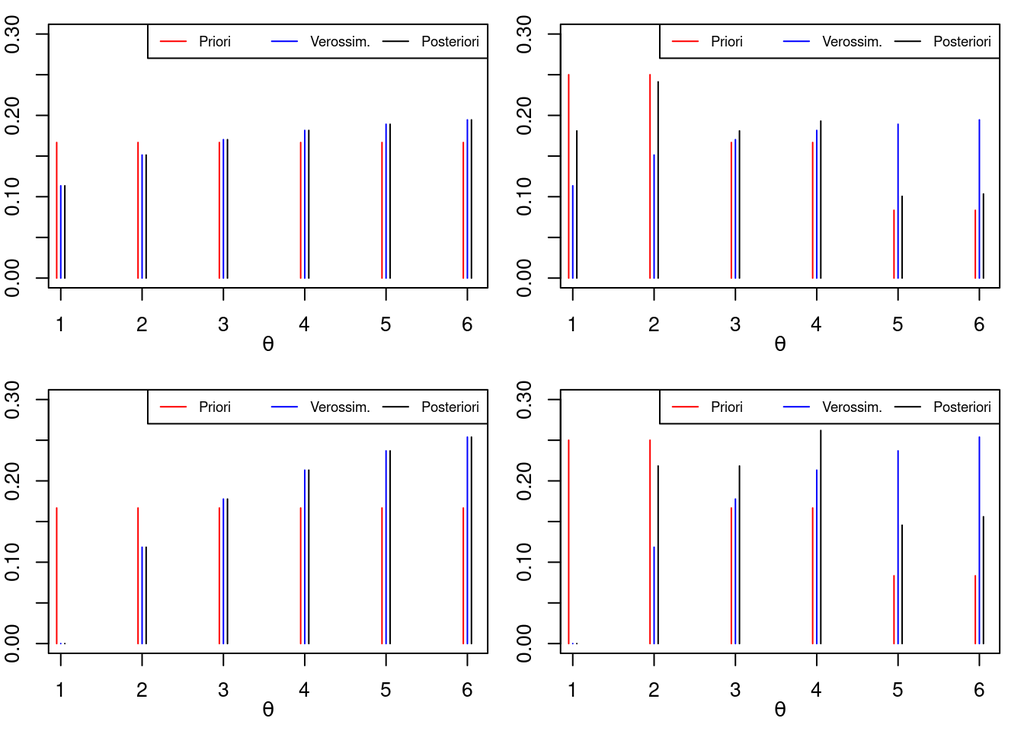

- Estude outras situações:
  1. a bola branca é retirada,
  2. há mais de uma bola branca na urna,
  3. outros “números de faces” do dado.

# Exemplo 5: Proporção de canhotos

1. Suponha que a proporção de canhotos na população é desconhecida e queremos estimá-la considerando apenas três possíveis valores: 0.05, 0.10 e 0.15 com probabilidades 0.60, 0.30 e 0.10, respectivamente.
1. Se em um grupo de 27 pessoas, 5 são canhotos, qual a distribuição a posteriori da proporção de canhotos na população?
2. Suponha que se verifica também um segundo grupo de 40 pessoas, 6 são canhotos. Qual a nova distribuição a posteriori da proporção de canhotos na população?
3. Verifique que considerando um só grupo de 27+40=67 pessoas com 5+6 = 11 canhotos, a distribuição a posteriori é a mesma.
2. Considere agora, no contexto da questão anterior, valores de $\theta$ entre 1 e 30% (valores percentuais inteiros) e priori proporcional a 5, 3 e 1 para $\theta \in \{1, 2, \ldots 10\}$, $\theta \in \{11, 12, \ldots 20\}$ e $\theta \in \{21, 22, \ldots 30\}$, respectivamente.

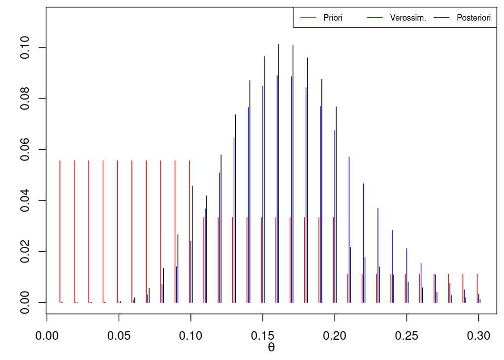

# Exemplo 6: Dados com distribuição Poisson

Suponha que o número de ocorrências de um determinado evento em um intervalo de tempo segue uma distribuição de Poisson com parâmetro $\theta$. Considera-se dez possíveis valores para $\theta$: $1, 2, 3, \ldots 10.$

1. Supondo com probabilidades iguais para o valor do parâmetro $\theta$:
1. se em um intervalo de tempo foram observadas 8 ocorrências, qual a distribuição posteriori de $\theta$?
2. se em um segundo intervalo de tempo foram observadas 6 ocorrências, qual a nova distribuição posteriori de $\theta$ considerando a priori inicial?
3. Verifique que considerando um só intervalo de tempo com 8+6=14 ocorrências, a distribuição posteriori é a mesma.
2. Repita itens anteriores considerando agora probabilidades para $\theta$ proporcionais a $0.25 \exp\{-0.25 \theta\}$.
3. Proponha outra priori para $\theta$ e repita os itens anteriores.
4. Considere agora que $\theta$ pode assumir qualquer valor positivo. Considere como priori valores em uma sequência $\{0.5, 1.0, 1.5, 2.0, \ldots 20\}$ proporcionais aos de uma distribuição gama com parâmetros $a=3$ e $b=1$. Repita os itens anteriores.

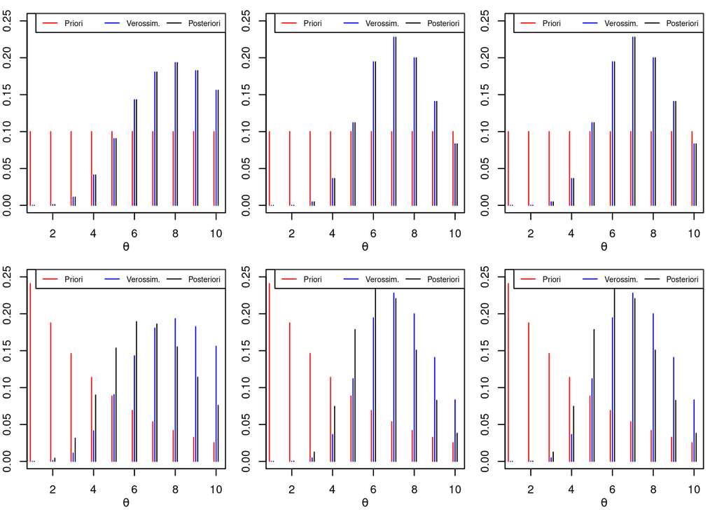